## Study Design and Algorithmic Bias

The principle “garbage in, garbage out” remains fundamental in data science. This exercise demonstrates how even well-implemented models cannot overcome the limitations of poor-quality data—a challenge that becomes increasingly significant in our current data landscape.

### Objectives

Our goal is this exercise is to illustrate how flaws in sampling design direct affect model predictions in ways that can perpetuate or amplify existing biases in various algorithmics.

### Procedure

1. **Data Acquisition**

   Download the dataset `Loan_Application_Data_subset.csv`, containing 10,000 randomly selected records from the [2023 FFIEC national loan-level dataset](https://ffiec.cfpb.gov/data-publication/dynamic-national-loan-level-dataset/2023), which encompasses national-level data on all home loans issued in the United States during 2023.
2. **Data Partitioning**

   First remove any loans that were not accepted:
   - A loan is denoted as accepted if it has loan_data$action_taken == 1

   Divide the dataset into two segments:
   - Training set: First 3,000 loan records
   - Test set: Remaining 1,955 loan records

   The training set will be used to develop a deliberately biased model to demonstrate how this bias affects subsequent analysis.

```r
# Load the dataset
loan_data <- read.csv("Loan_Application_Data_subset.csv")

loan_data = loan_data[loan_data$action_taken == 1,]

str(loan_data)
```

```
## 'data.frame':    4955 obs. of  100 variables:
##  $ X                                       : int  8957579 866486 7401176 9098266 3001437 11471297 3899797 1233158 4458859 9251814 ...
##  $ activity_year                           : int  2023 2023 2023 2023 2023 2023 2023 2023 2023 2023 ...
##  $ lei                                     : chr  "X05BVSK68TQ7YTOSNR22" "549300DD5QQUHO6PCH70" "549300K6K2IS7FRS7S09" "549300HFBEONQN2CK447" ...
##  $ derived_msa_md                          : int  35614 28940 26900 34940 40060 99999 99999 38060 33460 12580 ...
##  $ state_code                              : chr  "NY" "TN" "IN" "FL" ...
##  $ county_code                             : int  36081 47093 18057 12021 51087 56041 26091 4013 27003 24003 ...
##  $ census_tract                            : num  3.61e+10 4.71e+10 1.81e+10 1.20e+10 5.11e+10 ...
##  $ conforming_loan_limit                   : chr  "C" "C" "C" "C" ...
##  $ derived_loan_product_type               : chr  "Conventional:First Lien" "VA:First Lien" "Conventional:First Lien" "Conventional:First Lien" ...
##  $ derived_dwelling_category               : chr  "Single Family (1-4 Units):Site-Built" "Single Family (1-4 Units):Site-Built" "Single Family (1-4 Units):Site-Built" "Single Family (1-4 Units):Site-Built" ...
##  $ derived_ethnicity                       : chr  "Ethnicity Not Available" "Not Hispanic or Latino" "Not Hispanic or Latino" "Not Hispanic or Latino" ...
##  $ derived_race                            : chr  "Race Not Available" "White" "Black or African American" "White" ...
##  $ derived_sex                             : chr  "Female" "Male" "Male" "Joint" ...
##  $ action_taken                            : int  1 1 1 1 1 1 1 1 1 1 ...
```

[output cut: 86 more lines]

```r
# View the first few rows
head(loan_data)
```

```
##           X activity_year                  lei derived_msa_md state_code
## 1   8957579          2023 X05BVSK68TQ7YTOSNR22          35614         NY
## 2    866486          2023 549300DD5QQUHO6PCH70          28940         TN
## 4   7401176          2023 549300K6K2IS7FRS7S09          26900         IN
## 6   9098266          2023 549300HFBEONQN2CK447          34940         FL
## 9   3001437          2023 549300AG64NHILB7ZP05          40060         VA
## 10 11471297          2023 549300ESRQ6OLBB56N04          99999         WY
##    county_code census_tract conforming_loan_limit derived_loan_product_type
## 1        36081  36081063000                     C   Conventional:First Lien
## 2        47093  47093005912                     C             VA:First Lien
## 4        18057  18057110812                     C   Conventional:First Lien
## 6        12021  12021010436                     C   Conventional:First Lien
## 9        51087  51087200907                     C   Conventional:First Lien
## 10       56041  56041975401                     C            FHA:First Lien
##               derived_dwelling_category       derived_ethnicity
```

[output cut: 209 more lines]

```r
# Summary statistics
summary(loan_data)
```

```
##        X            activity_year      lei            derived_msa_md
##  Min.   :     280   Min.   :2023   Length:4955        Min.   :10180
##  1st Qu.: 2422206   1st Qu.:2023   Class :character   1st Qu.:21340
##  Median : 5308441   Median :2023   Mode  :character   Median :34980
##  Mean   : 5410102   Mean   :2023                      Mean   :39312
##  3rd Qu.: 8190524   3rd Qu.:2023                      3rd Qu.:42440
##  Max.   :11550110   Max.   :2023                      Max.   :99999
##
##   state_code         county_code     census_tract       conforming_loan_limit
##  Length:4955        Min.   : 1001   Min.   :1.001e+09   Length:4955
##  Class :character   1st Qu.:12127   1st Qu.:1.213e+10   Class :character
##  Mode  :character   Median :29077   Median :2.908e+10   Mode  :character
##                     Mean   :28735   Mean   :2.874e+10
##                     3rd Qu.:42091   3rd Qu.:4.209e+10
##                     Max.   :72137   Max.   :7.214e+10
##                     NA's   :32      NA's   :32
##  derived_loan_product_type derived_dwelling_category derived_ethnicity
##  Length:4955               Length:4955               Length:4955
##  Class :character          Class :character          Class :character
##  Mode  :character          Mode  :character          Mode  :character
##
##
##
##
##  derived_race       derived_sex         action_taken purchaser_type
##  Length:4955        Length:4955        Min.   :1     Min.   : 0.00
##  Class :character   Class :character   1st Qu.:1     1st Qu.: 0.00
##  Mode  :character   Mode  :character   Median :1     Median : 1.00
##                                        Mean   :1     Mean   :10.55
##                                        3rd Qu.:1     3rd Qu.: 3.00
##                                        Max.   :1     Max.   :72.00
##
##   preapproval      loan_type     loan_purpose     lien_status
##  Min.   :1.000   Min.   :1.00   Min.   : 1.000   Min.   :1.000
##  1st Qu.:2.000   1st Qu.:1.00   1st Qu.: 1.000   1st Qu.:1.000
##  Median :2.000   Median :1.00   Median : 1.000   Median :1.000
##  Mean   :1.968   Mean   :1.28   Mean   : 7.123   Mean   :1.231
##  3rd Qu.:2.000   3rd Qu.:1.00   3rd Qu.: 4.000   3rd Qu.:1.000
##  Max.   :2.000   Max.   :4.00   Max.   :32.000   Max.   :2.000
##
```

[output cut: 209 more lines]

```
##  Min.   :  0.00                 Min.   :   0.0
##  1st Qu.: 83.58                 1st Qu.: 843.5
##  Median :106.38                 Median :1187.0
##  Mean   :110.36                 Mean   :1240.5
##  3rd Qu.:131.43                 3rd Qu.:1576.5
##  Max.   :330.61                 Max.   :4825.0
##
##  tract_one_to_four_family_homes tract_median_age_of_housing_units
##  Min.   :   0                   Min.   : 0
##  1st Qu.:1218                   1st Qu.:23
##  Median :1619                   Median :35
##  Mean   :1667                   Mean   :36
##  3rd Qu.:2048                   3rd Qu.:49
##  Max.   :6025                   Max.   :80
##
```

```r
# Check for missing values
colSums(is.na(loan_data))
```

```
##                                        X
##                                        0
##                            activity_year
##                                        0
##                                      lei
##                                        0
##                           derived_msa_md
##                                        0
##                               state_code
##                                        5
##                              county_code
##                                       32
##                             census_tract
##                                       32
##                    conforming_loan_limit
##                                       36
##                derived_loan_product_type
##                                        0
##                derived_dwelling_category
##                                        0
##                        derived_ethnicity
##                                        0
##                             derived_race
##                                        0
##                              derived_sex
##                                        0
##                             action_taken
##                                        0
##                           purchaser_type
##                                        0
##                              preapproval
##                                        0
##                                loan_type
##                                        0
##                             loan_purpose
##                                        0
##                              lien_status
##                                        0
##                         reverse_mortgage
##                                        0
```

[output cut: 145 more lines]

```
##                                     4955
##                         tract_population
##                                        0
##        tract_minority_population_percent
##                                        0
##        ffiec_msa_md_median_family_income
##                                        0
##           tract_to_msa_income_percentage
##                                        0
##               tract_owner_occupied_units
##                                        0
##           tract_one_to_four_family_homes
##                                        0
##        tract_median_age_of_housing_units
##                                        0
```

3. **Initial Data Analysis**

   Before manipulation, examine the dataset using linear regression and the LASSO model provided in `Lending_LASSO.R`.

```r
# Create training and test sets
train_data <- loan_data[1:3000, ]
test_data <- loan_data[3001:4955, ]
train_data = train_data[,c('action_taken','loan_amount','income','interest_rate','derived_sex','derived_race')]
train_data = train_data[complete.cases(train_data),]
test_data = test_data[,c('action_taken','loan_amount','income','interest_rate','derived_sex','derived_race')]
test_data = test_data[complete.cases(test_data),]

train_data$interest_rate = as.numeric(train_data$interest_rate)
test_data$interest_rate = as.numeric(test_data$interest_rate)
# Verify the dimensions
dim(train_data)
```

```
## [1] 2842    6
```

```r
dim(test_data)
```

```
## [1] 1851    6
```

4. **Creating a Biased Dataset**

   To mimic the effect of a biased sample design, create a new dataset from the training data which oversamples low income female. For each datapoints in this biased sample:
   - Include female applicants with less than the median loan amount with 80% probability
   - Include non-female applicants (male, joint, or undisclosed) with 20% probability

```r
# Function to create biased dataset with specified sampling probabilities
create_biased_data <- function(data, female_prob = 0.8, non_female_prob = 0.2) {
  set.seed(456)

  # Create separate subsets for female and non-female applicants
  female_applicants <- data[((data$derived_sex == "Female")&(data$loan_amount <= 225000)), ]
  non_female_applicants <- data[!(((data$derived_sex == "Female")&(data$loan_amount <= 225000))), ]

  # Sample with specified probabilities
  female_sample <- female_applicants[sample(nrow(female_applicants),
                                           size = round(nrow(female_applicants) * female_prob)), ]

  non_female_sample <- non_female_applicants[sample(nrow(non_female_applicants),
                                                    size = round(nrow(non_female_applicants) * non_female_prob)), ]

  # Combine the samples to create the biased dataset
  biased_data <- rbind(female_sample, non_female_sample)

  # Shuffle the rows to mix the data
  biased_data <- biased_data[sample(nrow(biased_data)), ]

  return(biased_data)
}


biased_train_data = create_biased_data(train_data)
biased_train_data = biased_train_data[complete.cases(biased_train_data),]
```

5. **Model Comparison**
   - Fit a linear regression to both the biased and unbiased training dataset.
   - Generate loan amount predictions using the biased and unbiased linear regressions
   - Compare the predictions made using the biased and unbiased linear regressions. Are there any patterns in the errors?
   - Analyze prediction accuracy stratified by applicant demographics and identify whether certain groups receive better or worse estimates -If time, repeat the above with LASSO and random Forest

```r
# Create model matrix for LASSO on biased data
x_biased <- model.matrix(~ income + interest_rate + factor(derived_sex) + factor(derived_race) , data = biased_train_data)
y_biased <- biased_train_data$loan_amount

#linear regression
lm_model_biased <- lm(log(loan_amount) ~ income + interest_rate + factor(derived_sex), data = biased_train_data)


#linear regression
lm_model_unbiased <- lm(log(loan_amount) ~ income + interest_rate + factor(derived_sex) , data = train_data)
```

#Random forest

```r
library(randomForest)
rf_biased <- randomForest(log(loan_amount)~., data=biased_train_data, proximity=TRUE)

rf_unbiased <- randomForest(log(loan_amount)~., data=train_data[complete.cases(train_data),], proximity=TRUE)
```

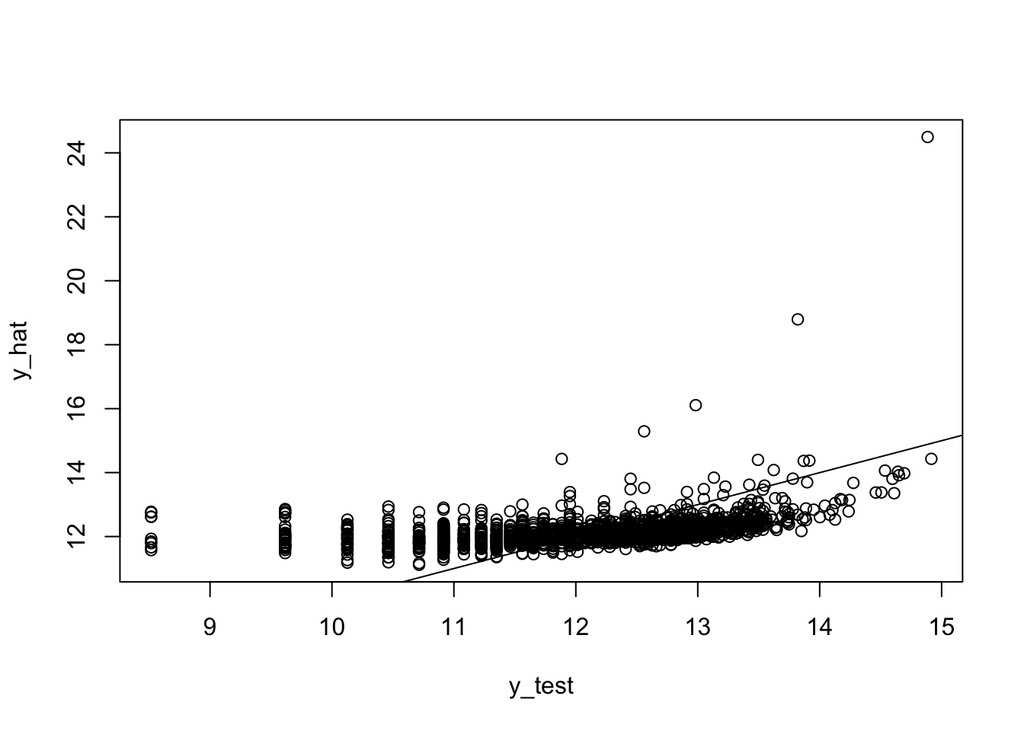

```r
#x_test <- model.matrix(~ income + interest_rate + factor(derived_sex) , data = test_data)

y_test <- log(test_data$loan_amount)
y_hat = (predict(lm_model_unbiased,newdata = test_data))
y_hat_biased =  (predict(lm_model_biased,newdata = test_data))


plot(y_test,y_hat)
abline(a=0,b=1)
```

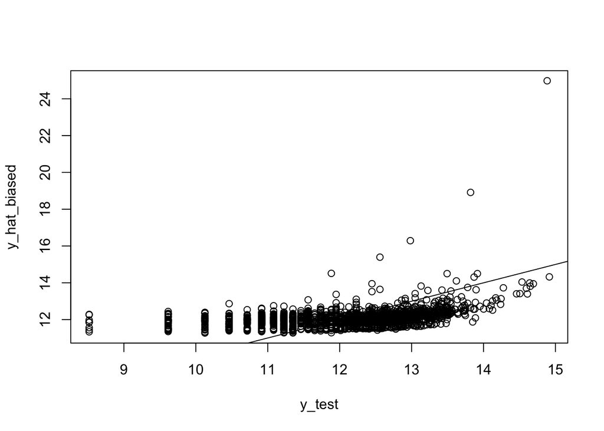

```r
plot(y_test,y_hat_biased)
abline(a=0,b=1)
```

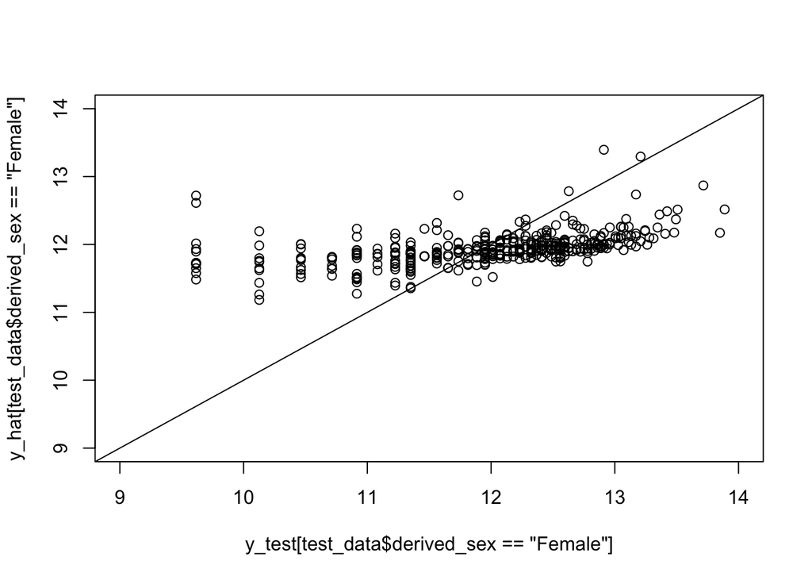

```r
plot(y_test[test_data$derived_sex == 'Female'],y_hat[test_data$derived_sex == 'Female'], ylim = c(9,14), xlim = c(9,14))
abline(a=0,b=1)
```

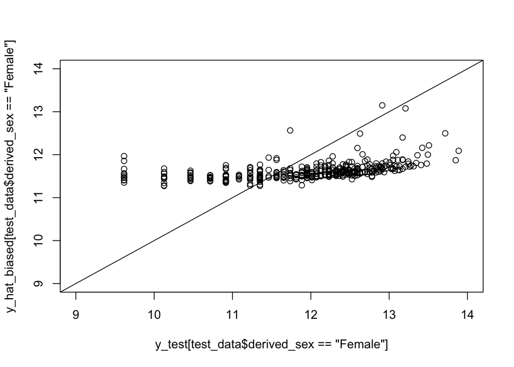

```r
plot(y_test[test_data$derived_sex == 'Female'],y_hat_biased[test_data$derived_sex == 'Female'], ylim = c(9,14), xlim = c(9,14))
abline(a=0,b=1)
```

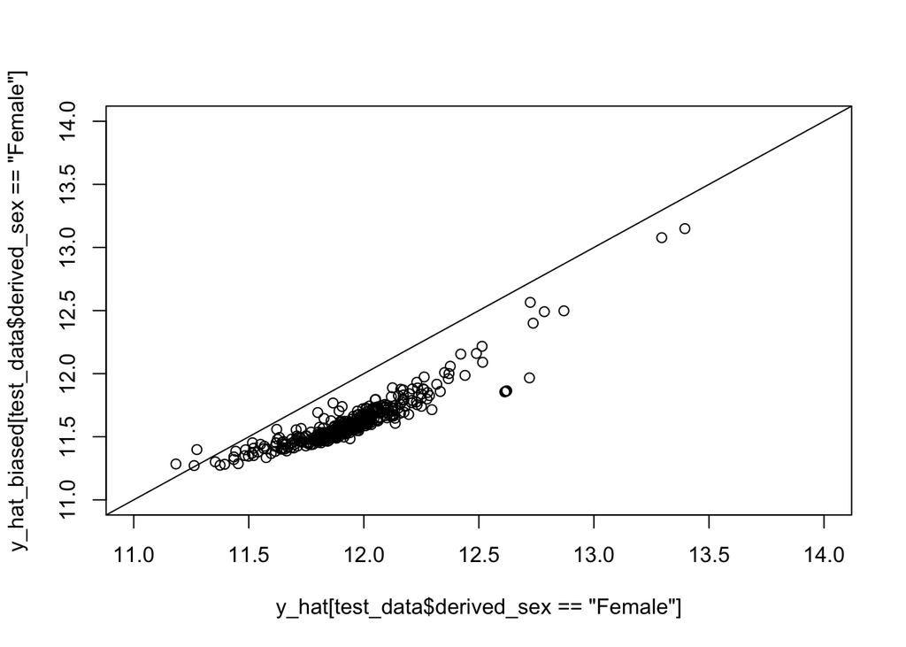

```r
plot(y_hat[test_data$derived_sex == 'Female'], y_hat_biased[test_data$derived_sex == 'Female'], ylim = c(11,14), xlim = c(11,14))
abline(a=0,b=1)
```

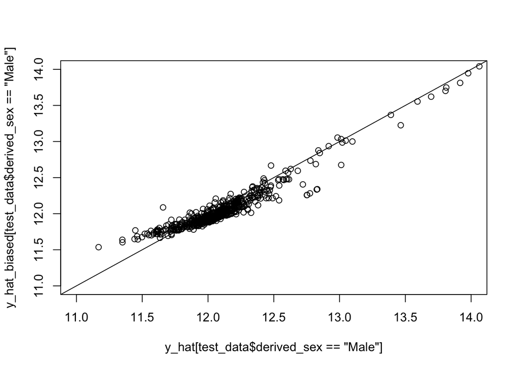

```r
plot(y_hat[test_data$derived_sex == 'Male'], y_hat_biased[test_data$derived_sex == 'Male'], ylim = c(11,14), xlim = c(11,14))
abline(a=0,b=1)
```

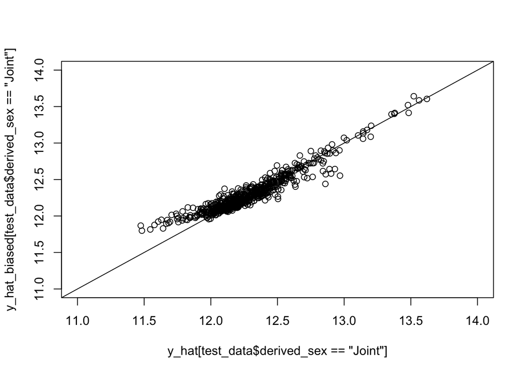

```r
plot(y_hat[test_data$derived_sex == 'Joint'], y_hat_biased[test_data$derived_sex == 'Joint'], ylim = c(11,14), xlim = c(11,14))
abline(a=0,b=1)
```

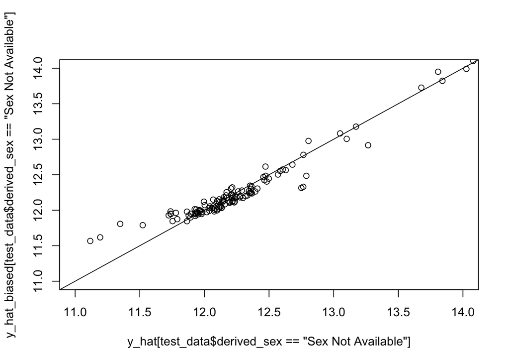

```r
plot(y_hat[test_data$derived_sex == 'Sex Not Available'], y_hat_biased[test_data$derived_sex == 'Sex Not Available'], ylim = c(11,14), xlim = c(11,14))
abline(a=0,b=1)
```

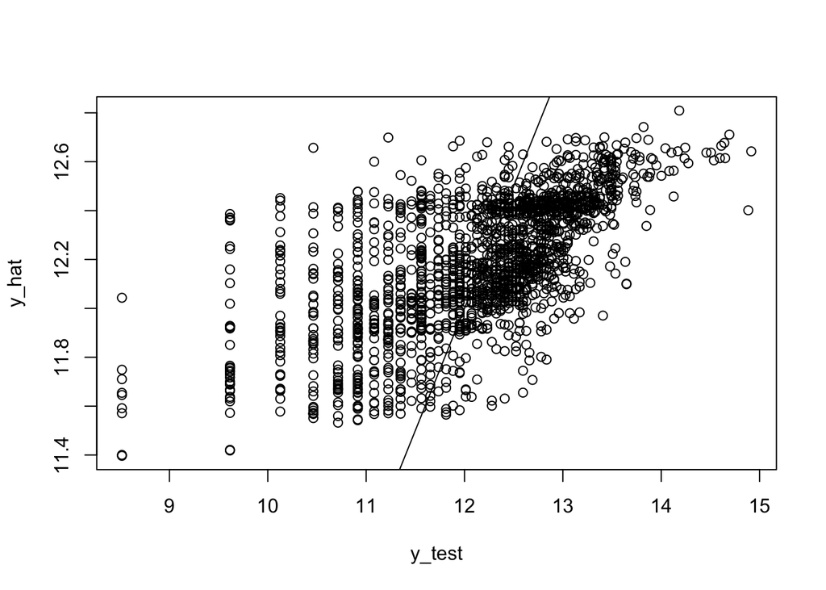

```r
y_test <- log(test_data$loan_amount)
y_hat = (predict(rf_unbiased,newdata = test_data))
y_hat_biased =  (predict(rf_biased,newdata = test_data))


plot(y_test,y_hat)
abline(a=0,b=1)
```

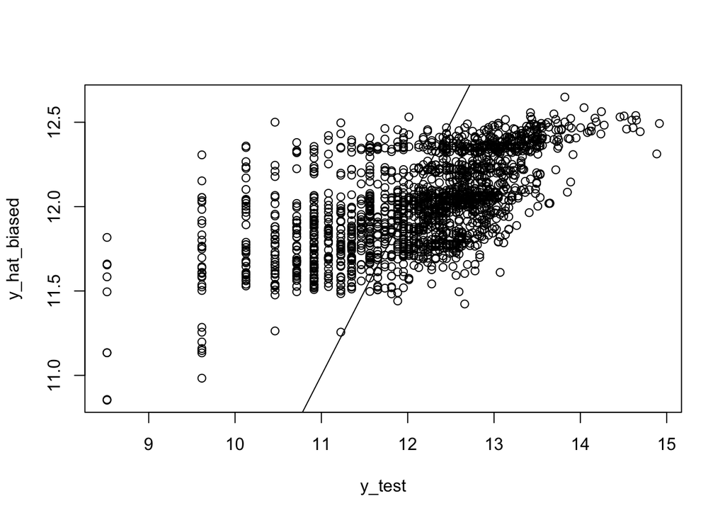

```r
plot(y_test,y_hat_biased)
abline(a=0,b=1)
```

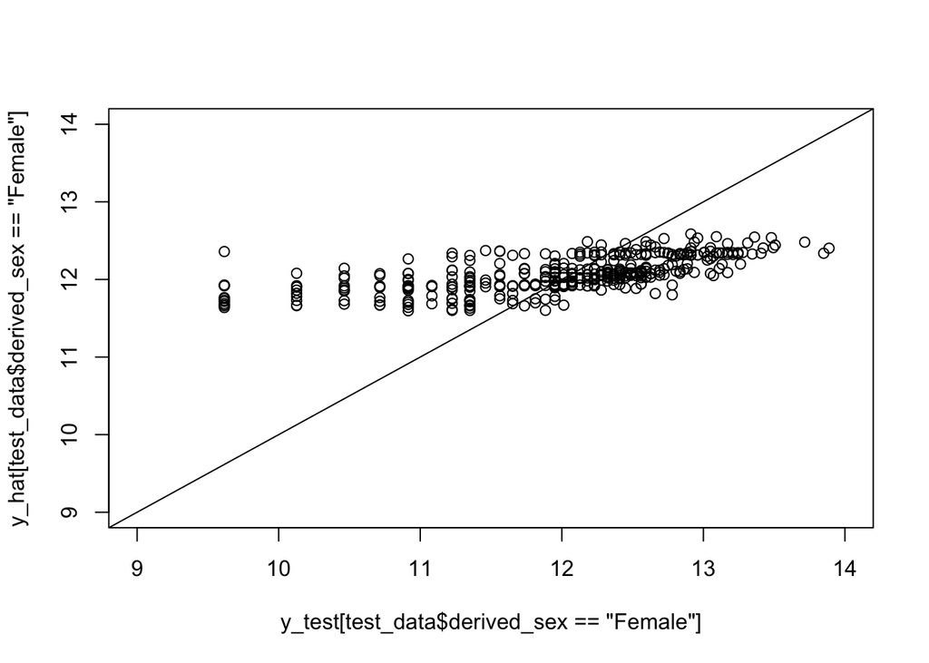

```r
plot(y_test[test_data$derived_sex == 'Female'],y_hat[test_data$derived_sex == 'Female'], ylim = c(9,14), xlim = c(9,14))
abline(a=0,b=1)
```

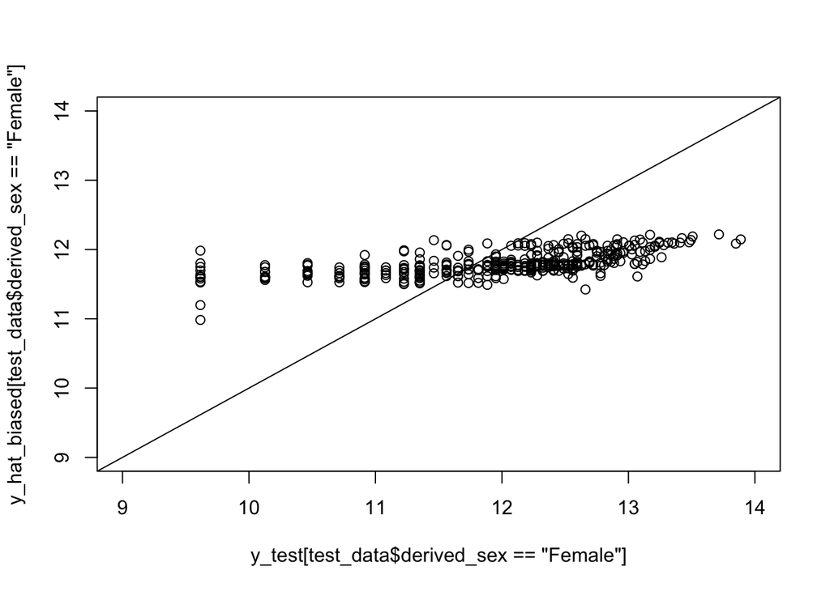

```r
plot(y_test[test_data$derived_sex == 'Female'],y_hat_biased[test_data$derived_sex == 'Female'], ylim = c(9,14), xlim = c(9,14))
abline(a=0,b=1)
```

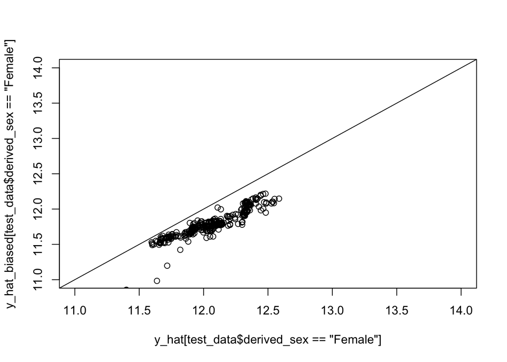

```r
plot(y_hat[test_data$derived_sex == 'Female'], y_hat_biased[test_data$derived_sex == 'Female'], ylim = c(11,14), xlim = c(11,14))
abline(a=0,b=1)
```

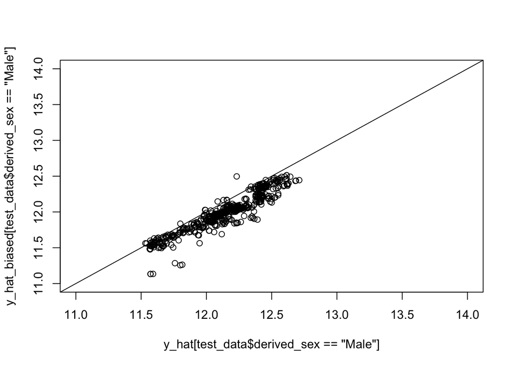

```r
plot(y_hat[test_data$derived_sex == 'Male'], y_hat_biased[test_data$derived_sex == 'Male'], ylim = c(11,14), xlim = c(11,14))
abline(a=0,b=1)
```

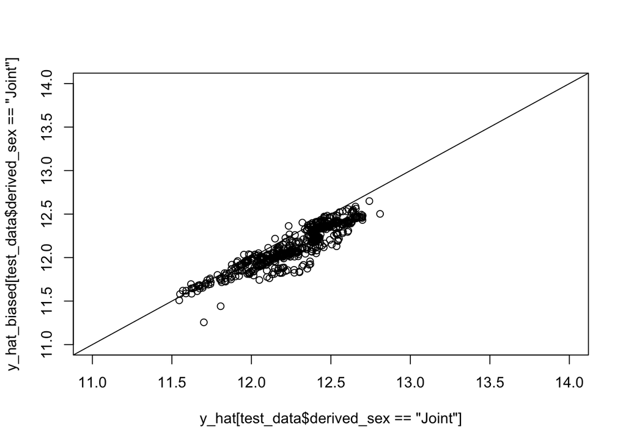

```r
plot(y_hat[test_data$derived_sex == 'Joint'], y_hat_biased[test_data$derived_sex == 'Joint'], ylim = c(11,14), xlim = c(11,14))
abline(a=0,b=1)
```

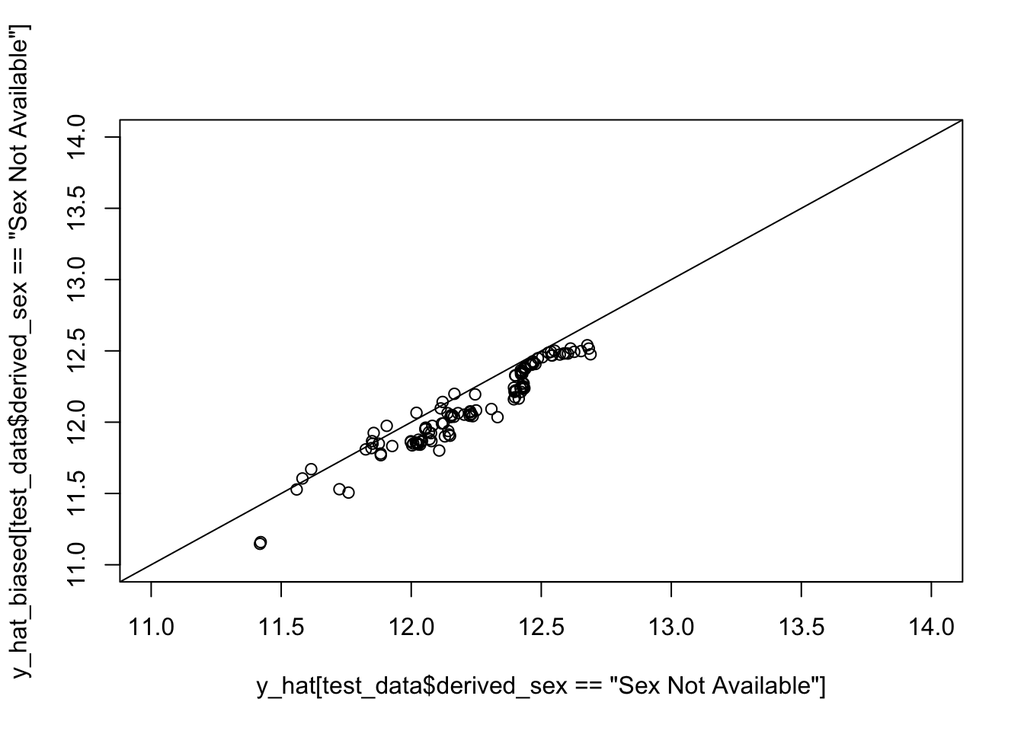

```r
plot(y_hat[test_data$derived_sex == 'Sex Not Available'], y_hat_biased[test_data$derived_sex == 'Sex Not Available'], ylim = c(11,14), xlim = c(11,14))
abline(a=0,b=1)
```

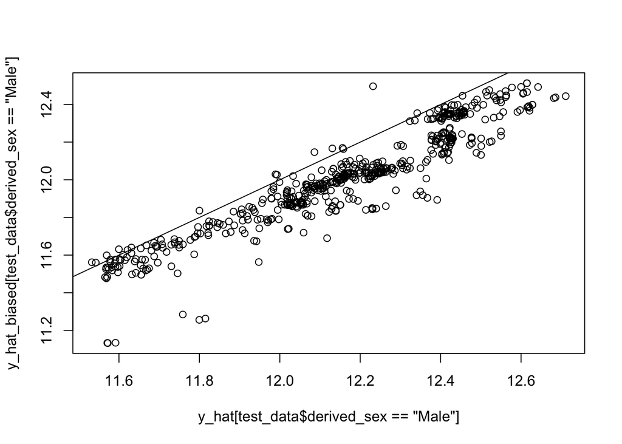

```r
plot(y_hat[test_data$derived_sex == 'Male'], y_hat_biased[test_data$derived_sex == 'Male'])
abline(a=0,b=1)
```

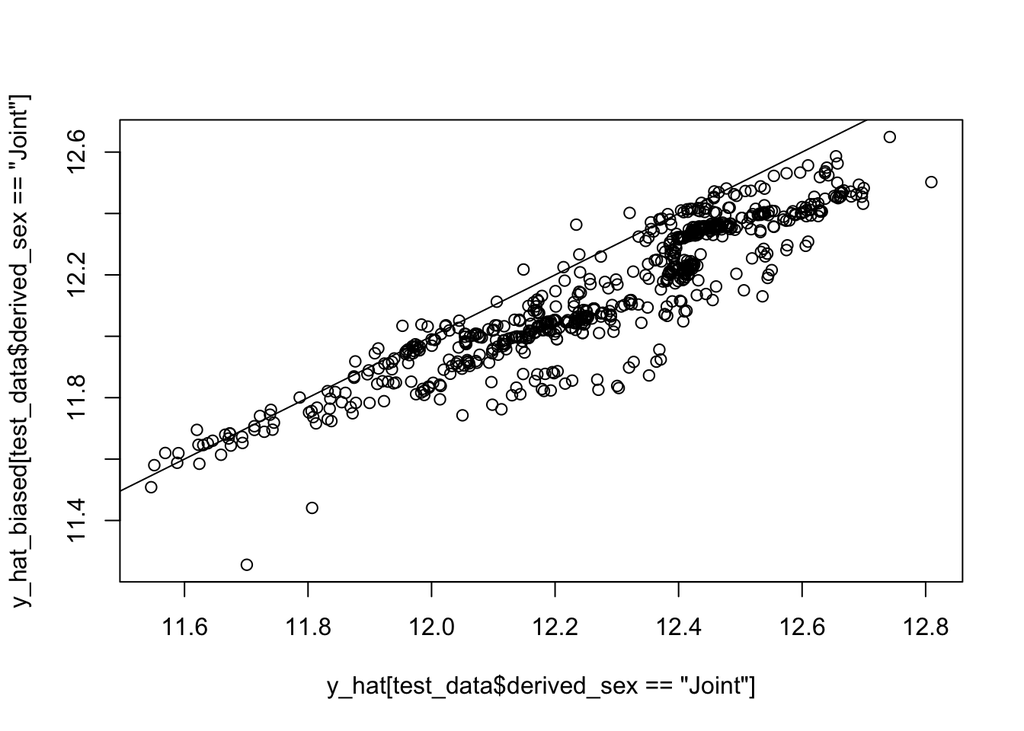

```r
plot(y_hat[test_data$derived_sex == 'Joint'], y_hat_biased[test_data$derived_sex == 'Joint'])
abline(a=0,b=1)
```

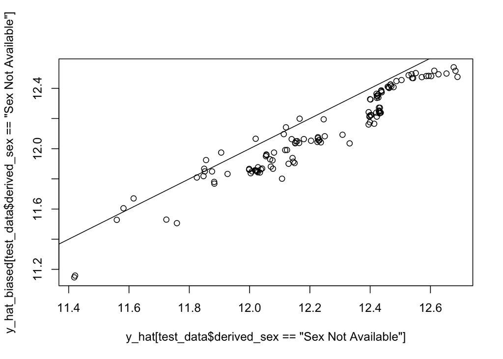

```r
plot(y_hat[test_data$derived_sex == 'Sex Not Available'], y_hat_biased[test_data$derived_sex == 'Sex Not Available'])
abline(a=0,b=1)
```

7. **Sensitivity Analysis**

   Vary the 80/20 probability split used in step 4 to create datasets with different levels of bias:
   - Implement a range of sampling probabilities
   - Assess how varying degrees of sampling bias affect prediction accuracy
   - Determine the threshold at which sampling bias begins to significantly compromise model performance
   - Establish criteria for “reasonable” accuracy and identify the maximum tolerable sampling bias